# IODS course project

### Choosing variables for analysis and setting hypothesis.

In this exercise, I’m going to study four interesting variables which might explain high alcohol consumption. I choose student’s gender (sex), mother’s education (Medu), extra-curricular activities (activites) and going out with friends (goout) as the variables of interest. I hypothesise:

1. The risk of being “high user” is greater in boys compared to girls
2. Mother’s higher education is related to less alcohol consumption
3. Having extra curricular activities is associated with less alcohol consumption.
4. Going out with friens is associated with higher alcohol consumption

##### **Descriptive results of the variables of interest**

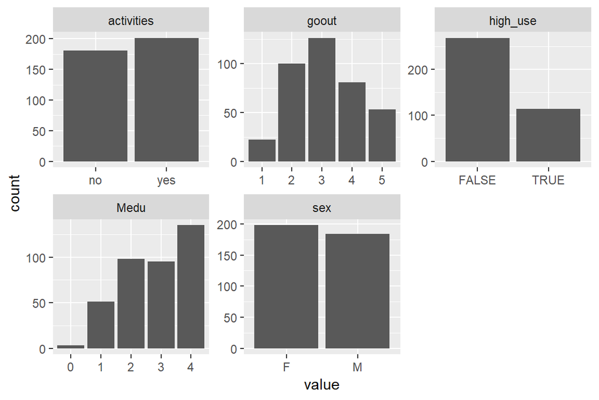

```
## # A tibble: 4 x 3
## # Groups:   high_use [?]
##   high_use sex   count
##   <lgl>    <fct> <int>
## 1 FALSE    F       156
## 2 FALSE    M       112
## 3 TRUE     F        42
## 4 TRUE     M        72
```

As hypothesised, it looks like the sex is associated with alcohol use. There are more girls in low achohol use category whereas in high alcohol consumption category there are more boys.

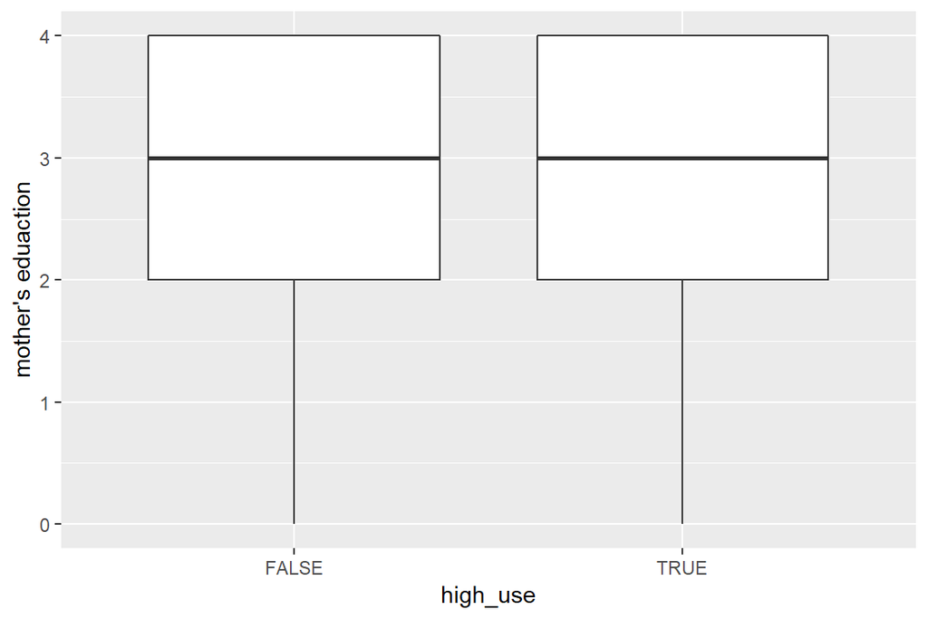

The boxplots look so similar in both groups that mother’s education probably is not related to alcohol consumption. The observation is contradictory to my hypothesis, I assumed tha students with high alcohol consumption would have less educated mothers. Mother’s education probably should not be threated as continuous variable, but I did not have time find better solution for this variable.

```
## # A tibble: 4 x 3
## # Groups:   high_use [?]
##   high_use activities count
##   <lgl>    <fct>      <int>
## 1 FALSE    no           122
## 2 FALSE    yes          146
## 3 TRUE     no            59
## 4 TRUE     yes           55
```

Based on the crosstabulation above, it seems that there is no clear difference in alcohol consumption if student has or does not have extra-curricular activities. This is also contradictory to my hypothesis. I assumed that students with high alcohol consumption would have less extra-curricular activites. There might be a slight tendency towards that direction, but the diffences between high vs. low alchol consumption groups are not very large.

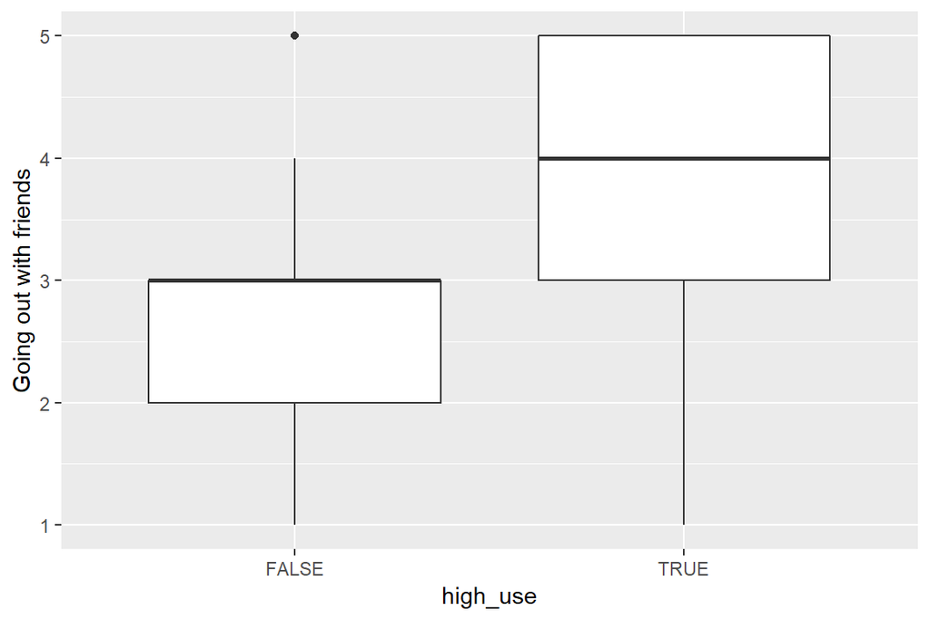

Based on the boxplot above it looks like going out is associated with high alcohol use. Students with high alcohol consumption had higher scores for goint out with friends. The observation is in line with my hypothesis.

### Logistic regression

##### **The first model including all the variables of interest**

```
##                       OR       2.5 %     97.5 %
## (Intercept)   0.02813744 0.009360692 0.07827196
## sexM          2.57275527 1.579024853 4.24911649
## Medu          0.96762873 0.773590466 1.21225481
## activitiesyes 0.62945337 0.382718509 1.02744279
## goout         2.17489411 1.731365747 2.76975185
```

As assumed when exploring the variables, only sex and going out are significantly associated with the alcohol consumtion, since the confidence intervals of ORs for these variables do not include 1. OR for boys is 2.6, meaning that boys have 2.6 times higher odds of high alcohol consumption compared to girls. OR for going out is 2.1, meaning that each 1 point increase in going out scale (from 1 to 5) is associated with 2.1 higher odds of high alcohol consumption.

##### **Predictive power of the model**

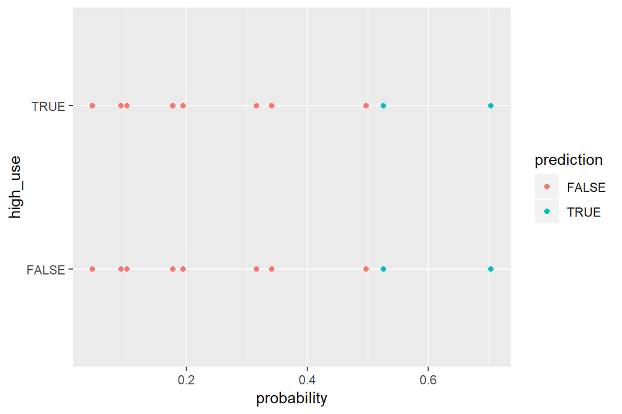

```
##         prediction
## high_use      FALSE       TRUE        Sum
##    FALSE 0.65706806 0.04450262 0.70157068
##    TRUE  0.16492147 0.13350785 0.29842932
##    Sum   0.82198953 0.17801047 1.00000000
```

I wonder if my graph went wrong, since it does look a bit strange to me. I do not really know hot to interpret it.

Based on the crosstabulation of predicted vs. observed values, it looks like approximattely 21 % of the students (0.045 + 0.165 x 100 %) end up incorrectly classified. It is probably a bit better than just guessing.

# Rstudio Exercise 4

### Description of the data used for the exercise

This week we use the **Boston** dataset which is included in the MASS package. The dataset is collected by the U.S Census Servise and it contains information about housing in the area of Boston Mass. There are 506 cases and 14 variables in the dataset.

```r
# accessing the MASS package
library(MASS)

# loading the data
data("Boston")

# exploring the structure and dimensions
str(Boston)
```

```
## 'data.frame':    506 obs. of  14 variables:
##  $ crim   : num  0.00632 0.02731 0.02729 0.03237 0.06905 ...
##  $ zn     : num  18 0 0 0 0 0 12.5 12.5 12.5 12.5 ...
##  $ indus  : num  2.31 7.07 7.07 2.18 2.18 2.18 7.87 7.87 7.87 7.87 ...
##  $ chas   : int  0 0 0 0 0 0 0 0 0 0 ...
##  $ nox    : num  0.538 0.469 0.469 0.458 0.458 0.458 0.524 0.524 0.524 0.524 ...
##  $ rm     : num  6.58 6.42 7.18 7 7.15 ...
##  $ age    : num  65.2 78.9 61.1 45.8 54.2 58.7 66.6 96.1 100 85.9 ...
##  $ dis    : num  4.09 4.97 4.97 6.06 6.06 ...
##  $ rad    : int  1 2 2 3 3 3 5 5 5 5 ...
##  $ tax    : num  296 242 242 222 222 222 311 311 311 311 ...
##  $ ptratio: num  15.3 17.8 17.8 18.7 18.7 18.7 15.2 15.2 15.2 15.2 ...
##  $ black  : num  397 397 393 395 397 ...
##  $ lstat  : num  4.98 9.14 4.03 2.94 5.33 ...
##  $ medv   : num  24 21.6 34.7 33.4 36.2 28.7 22.9 27.1 16.5 18.9 ...
```

```r
dim(Boston)
```

```
## [1] 506  14
```